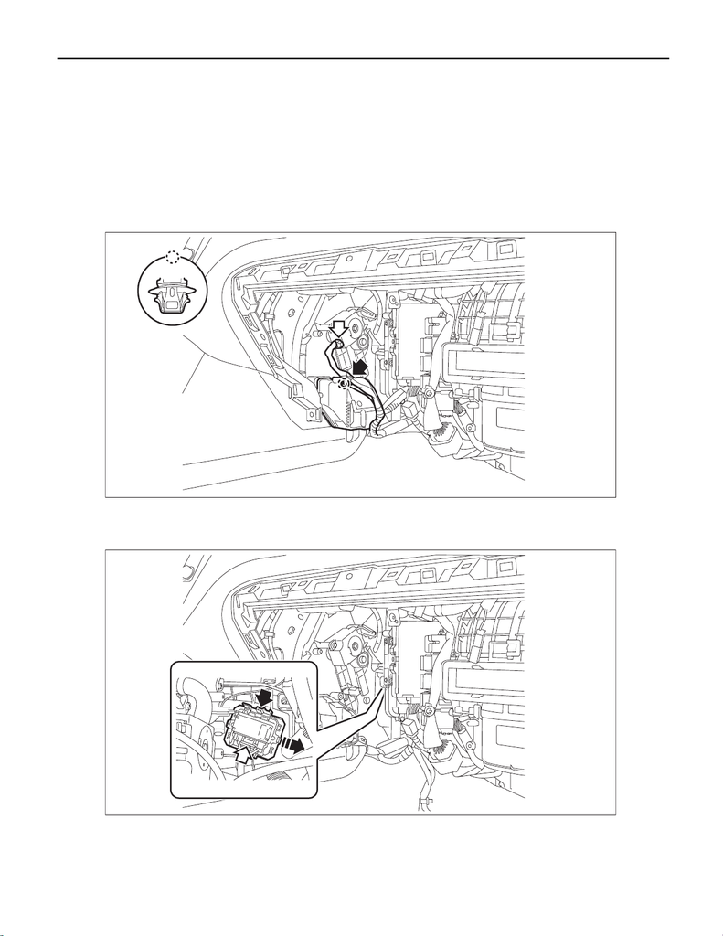

Power Transistor (Auto A/C Model)

HVAC SYSTEM (HEATER, VENTILATOR AND A/C)

11.Power Transistor (Auto A/C Model)

A: REMOVAL

1) Disconnect the ground cable from battery. <Ref. to NT-5, BATTERY, NOTE, Note.>

NOTE:

For models other than STI model, disconnect the ground terminal from battery sensor.

2) Remove the glove box. <Ref. to EI-63, REMOVAL, Glove Box.>

3) Remove the screws and remove the duct - foot RH.

NOTE:

Remove the connector and harness clip of the motor - actuator mix RH, and move the harness aside.

4) Remove the power transistor.

(1) Disconnect the connector.

(2) Remove the power transistor while pressing the power transistor claw part and sliding it.

AC-02722

AC-02709

Power Transistor (Auto A/C Model)

HVAC SYSTEM (HEATER, VENTILATOR AND A/C)

B: INSTALLATION

1) Install the power transistor.

2) Install the duct - foot RH.

3) Install the glove box.

4) Connect the battery ground terminal. <Ref. to NT-5, BATTERY, NOTE, Note.>

NOTE:

For models other than STI model, connect the ground terminal to battery sensor.